# MOMs Cost Effective Analysis

**Biostatistician:** Licza Lobo, Jacob Parquet

**Principal Investigator:** Ali Jalali, PhD; Mila Sun, PhD; Sean M. Murphy, PhD

*July 20, 2026*

# Study background information

The Maternal Opioid Misuse (MOMs) trial was a multicenter, randomized clinical trial comparing extended-release buprenorphine (BUP-XR) with sublingual buprenorphine (BUP-SL) for the treatment of opioid use disorder during pregnancy. Participants were randomized to receive either BUP-XR or BUP-SL and were followed prospectively throughout pregnancy and delivery.

The analysis was conducted from a healthcare sector perspective to evaluate the cost-effectiveness of BUP-XR compared with BUP-SL by jointly considering healthcare costs with maternal and infant clinical outcomes.

## Outcomes

### Costs

Cost were computed in the following manner:

- ED Costs = Number of ED Visits x $760
- Inpatient Costs = Number of Inpatient Hospitalizations x $3,718
- Acute Costs = ED Costs + Inpatient Costs
- Outpatient Costs = (Days in Outpatient Hospital + Number of Medical Doctor Visits + Number of Other Medical Visits) x $528
- Primary Cost = Acute Costs + Outpatient Costs

Cost weights were derived from 2023 Medicaid expenditure estimates obtained from MEPS data and inflated to 2025 U.S. dollars.

### Effect (Quality Adjusted Life Years)

Quality-adjusted life years (QALYs) were estimated from health-related quality of life (HRQoL) measured using the Patient-Reported Outcomes Measurement Information System (PROMIS). HRQoL scores collected at each follow-up assessment were converted into utility values and used to estimate QALYs over the 12-month period following randomization. QALYs were calculated using the trapezoidal rule, which assumes a linear change in utility between consecutive monthly follow-up assessments and estimates the area under the utility curve over time.

### Effect (Abstinence)

Abstinent weeks were estimated using weekly urine drug screening (UDS) results collected during the first 52 weeks following randomization. Baseline screening visits (S01) were excluded, and each participant’s subsequent UDS visits were ordered chronologically and assigned a study week. A negative illicit opioid urine screen was coded as one abstinent week, while a positive or missing urine screen was coded as non-abstinent, consistent with a conservative assumption that missing tests represented opioid use.

### Effect (Infant Opioid Treatment Days)

Infant opioid treatment days were defined as the total number of days each infant received pharmacologic treatment for neonatal opioid withdrawal syndrome (NOWS) during the birth hospitalization. Infants who did not require pharmacologic treatment were assigned zero treatment days. The adjusted mean number of treatment days for each treatment group was estimated using a covariate-adjusted two-part model, with logistic regression modeling the probability of receiving any treatment and a Poisson regression modeling the number of treatment days among infants who received treatment.

# Aims

1. Descriptive statistics of study sample
2. Marginal effect of MOMs intervention on effectiveness and healthcare costs at 6 and 12 months
3. Scatterplot of bootstrapped cost and effect ATE cloud
4. Proportion cost and effect favorable, proportion dominant
5. Cost-effectiveness Acceptability Curve (CEAC) Analysis

# Results

## 1. Descriptive statistics of study sample

### Table 1. Mother characteristics

| **Characteristic** | **BUP-SL** N = 71<sup>1</sup> | **BUP-XR** N = 69<sup>1</sup> | **Overall** N = 140<sup>1</sup> | **p-value**<sup>2</sup> |
| --- | --- | --- | --- | --- |
| Estimated Gestational Age at Randomization (weeks) | 22 (16, 26) | 22 (16, 28) | 22 (16, 27) | 0.5 |
| Mother's Age at Randomization (years) | 31.0 (29.0, 34.0) | 32.0 (29.0, 34.0) | 31.0 (29.0, 34.0) | >0.9 |
| Race |  |  |  | 0.5 |
| Black | 7 (9.9%) | 3 (4.3%) | 10 (7.1%) |  |
| Other | 7 (9.9%) | 7 (10%) | 14 (10%) |  |
| White | 57 (80%) | 59 (86%) | 116 (83%) |  |
| Ethnicity |  |  |  | 0.7 |
| Hispanic | 6 (8.5%) | 4 (5.8%) | 10 (7.1%) |  |
| Not Hispanic | 65 (92%) | 65 (94%) | 130 (93%) |  |
| Education Level |  |  |  | 0.12 |
| Above a Highschool Education | 36 (51%) | 26 (38%) | 62 (44%) |  |
| Highschool Diploma, GED, or Less | 35 (49%) | 43 (62%) | 78 (56%) |  |
| Employment Status |  |  |  | 0.3 |
| Employed | 21 (30%) | 26 (38%) | 47 (34%) |  |
| Unemployed | 50 (70%) | 43 (62%) | 93 (66%) |  |
| Marriage Status |  |  |  | 0.8 |
| Married | 11 (16%) | 10 (14%) | 21 (15%) |  |
| Not Married | 57 (84%) | 59 (86%) | 116 (85%) |  |
| Unknown | 3 | 0 | 3 |  |
| Healthcare Cost Data Available |  |  |  |  |
| Available | 71 (100%) | 69 (100%) | 140 (100%) |  |
| Urine Follow-up Available |  |  |  | 0.2 |
| Available | 68 (96%) | 69 (100%) | 137 (98%) |  |
| Missing | 3 (4.2%) | 0 (0%) | 3 (2.1%) |  |
| Infant Outcome Available |  |  |  | 0.7 |
| Available | 69 (97%) | 66 (96%) | 135 (96%) |  |
| Missing | 2 (2.8%) | 3 (4.3%) | 5 (3.6%) |  |
| Primary Healthcare Cost (6 months) | 10,454 (5,280, 15,544) | 7,392 (5,280, 11,088) | 8,448 (5,280, 14,171) | 0.046 |
| Primary Healthcare Cost (12 months) | 12,630 (6,336, 19,430) | 8,448 (6,040, 12,248) | 10,000 (6,336, 15,164) | 0.017 |
| Abstinent Weeks (6 months) | 23 (17, 25) | 24 (21, 25) | 23 (19, 25) | 0.2 |
| Unknown | 3 | 0 | 3 |  |
| Abstinent Weeks (12 months) | 45 (24, 48) | 45 (27, 49) | 45 (26, 49) | 0.7 |
| Unknown | 3 | 0 | 3 |  |
| Infant Opioid Treatment Days | 0 (0, 2) | 0 (0, 3) | 0 (0, 3) | 0.8 |
| Unknown | 3 | 4 | 7 |  |

<sup>1</sup> Median (Q1, Q3); n (%)  
<sup>2</sup> Wilcoxon rank sum test; Fisher’s exact test; Pearson’s Chi-squared test; NA

## 2. Marginal effect of MOMs intervention on Effectiveness and Healthcare costs

### Cost: Healthcare Costs

To account for the skewed distribution of healthcare cost outcome, a two-part model was fit. The first part of the model used logistic regression to estimate the probability of incurring any healthcare costs over the 6-month follow-up period. The second part used a gamma regression model to estimate healthcare costs among individuals with non-zero costs. We adjust for maternal age, ethnicity, education level, employment status, marriage status, and estimated gestational age in weeks.

### Effect: QALYS

This approach fits a probit regression model for the outcome while weighting each observation by the inverse probability of being observed (i.e., not missing). The inverse probability weights are estimated from a model predicting missingness using baseline covariates. This procedure corrects for potential bias due to informative missingness by giving more weight to observations that are underrepresented because of missing data, producing a covariate-adjusted estimate of the treatment effect while preserving the original sample structure.

This was the approach used by Murphy et al. in original CEA analysis.

### Effect: Expected abstinent weeks over 6 months

Using the same individuals included in each bootstrap sample from the cost analysis, all available urine drug screening data were used to fit a binomial model for abstinence/opioid negativity, adjusting for maternal age, ethnicity, education level, employment status, marriage status, and estimated gestational age in weeks. We predict the expected number of weeks abstinent from opioid use at each week over the primary study timepoint. G-computation methods were then used to estimate the difference in mean abstinent weeks between treatment groups within each bootstrap sample, along with corresponding standard deviations and 95% confidence intervals.

As per the protocol, missing urine tests were assumed to be positive for opioid use.

### Effect: Infant Days Treated for Opioid Withdrawl

Using the same individuals included in each bootstrap sample from the cost analysis, infant opioid treatment days during the birth hospitalization were analyzed using a covariate-adjusted two-part model, adjusting for maternal age, ethnicity, education level, employment status, marital status, and estimated gestational age at randomization. The first part modeled the probability of requiring any pharmacologic treatment for neonatal opioid withdrawal syndrome, while the second part modeled the number of treatment days among infants who received treatment using a Poisson regression. Average marginal effects were computed within each bootstrap sample to estimate the adjusted difference in mean infant opioid treatment days between treatment groups. Standard deviations and 95% confidence intervals were obtained from the distribution of the bootstrap estimates.

** Note: The AME R package does not compute mean effect per arm.

Adjusted Treatment Effects on Healthcare Costs, Expected Abstinent Weeks, Infant Opioid Treatment Days, and Quality-Adjusted Life Years at 6 and 12 Months

| Outcome | 6 Months BUP-SL Mean | 6 Months BUP-XR Mean | 6 Months ATE (95% CI) | 6 Months P-value | 12 Months BUP-SL Mean | 12 Months BUP-XR Mean | 12 Months ATE (95% CI) | 12 Months P-value |
| --- | --- | --- | --- | --- | --- | --- | --- | --- |
| Emergency Department Cost | — | — | -$218 (-$648, $250) | 0.342 | — | — | -$229 (-$724, $323) | 0.408 |
| Inpatient Cost | — | — | -$1,210 (-$2,536, -$182) | 0.024 | — | — | -$1,235 (-$2,752, -$66) | 0.038 |
| Total Acute Care Cost | — | — | -$1,520 (-$3,159, -$114) | 0.040 | — | — | -$1,536 (-$3,373, $82) | 0.060 |
| Outpatient Treatment Cost | — | — | -$3,164 (-$6,322, -$262) | 0.036 | — | — | -$4,082 (-$8,547, -$375) | 0.032 |
| Primary Healthcare Cost | — | — | -$4,501 (-$9,260, -$807) | 0.018 | — | — | -$5,449 (-$11,181, -$774) | 0.022 |
| Expected Abstinent Weeks | 19.81 | 20.78 | 0.97 (-1.18, 3.08) | 0.400 | 36.71 | 36.96 | 0.26 (-4.80, 5.34) | 0.912 |
| Infant Opioid Treatment Days | — | — | -1.26 (-4.55, 1.62) | 0.410 | — | — | -1.26 (-4.55, 1.62) | 0.410 |
| QALYs | 0.194 | 0.222 | 0.027 (-0.000, 0.053) | 0.052 | 0.413 | 0.468 | 0.055 (-0.005, 0.111) | 0.064 |

## 3. Scatterplot of Bootstrapped Cost and Effect ATE cloud (Over 1 Year Follow-Up)

### Effect: QALYs

Each point represents one bootstrap sample’s estimated treatment effect on primary healthcare costs and QALYs, illustrating the relationship between costs and effectiveness across replications.

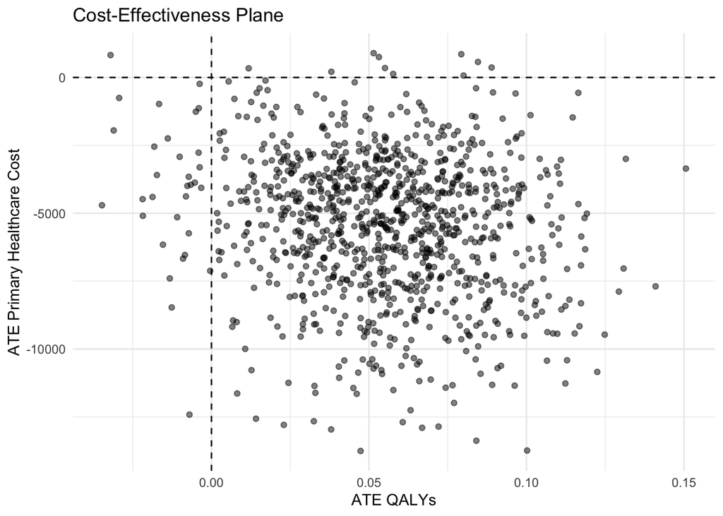

### Effect: Abstinent Weeks

Each point represents one bootstrap sample’s estimated treatment effect on primary healthcare costs and expected abstinent weeks, illustrating the relationship between costs and effectiveness across replications.

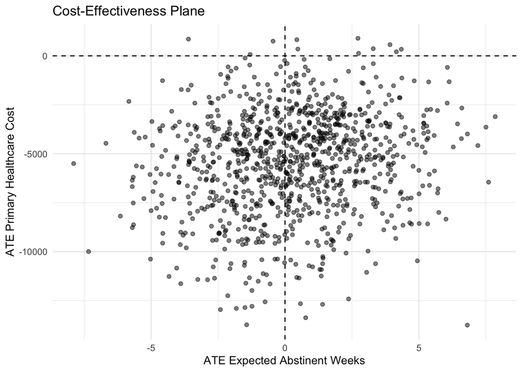

### Effect: Infant Days Avoided

Each point represents one bootstrap sample’s estimated treatment effect on primary healthcare costs and infant opioid treatment days avoided. illustrating the relationship between costs and effectiveness across replications.

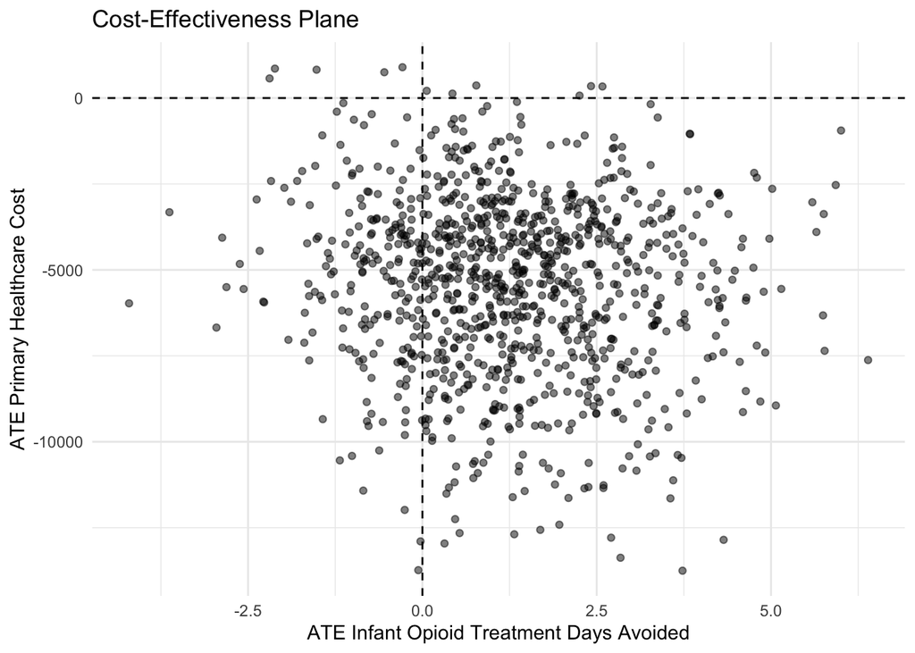

## 4. Proportion Cost and Effect Favorable (Proportion Dominant) (Over 1 Year Follow-Up)

### Effect: QALYs

| Probability ΔEffect > 0 (More effective) | Probability ΔCost < 0 (Cost-saving) | Probability BUP-XR dominant (Cost-saving & More effective) |
| --- | --- | --- |
| 96.8% | 98.9% | 95.8% |

### Effect: Abstinent Weeks

| Probability ΔEffect > 0 (More effective) | Probability ΔCost < 0 (Cost-saving) | Probability BUP-XR dominant (Cost-saving & More effective) |
| --- | --- | --- |
| 54.4% | 98.9% | 53.6% |

### Effect: Infant Days Avoided

| Probability ΔEffect > 0 (More effective) | Probability ΔCost < 0 (Cost-saving) | Probability BUP-XR dominant (Cost-saving & More effective) |
| --- | --- | --- |
| 79.5% | 98.9% | 78.9% |

## 5. Cost-effectiveness Acceptability Curve (CEAC)

The proportion of bootstrap replicates in which the net monetary benefit (NMB) was greater than zero was calculated across willingness-to-pay (WTP) thresholds ranging from $10,000 to $500,000 per additional QALY gained.

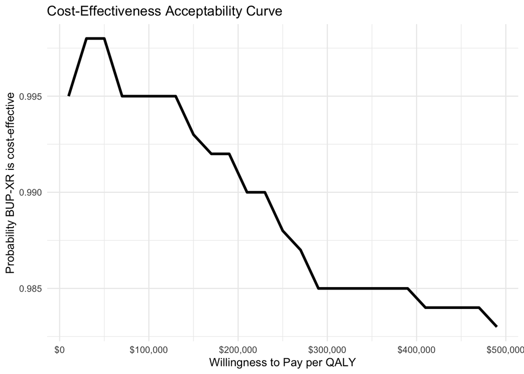

The proportion of bootstrap replicates in which the net monetary benefit (NMB) was greater than zero was calculated across willingness-to-pay (WTP) thresholds ranging from $10,000 to $500,000 per additional abstinent week gained.

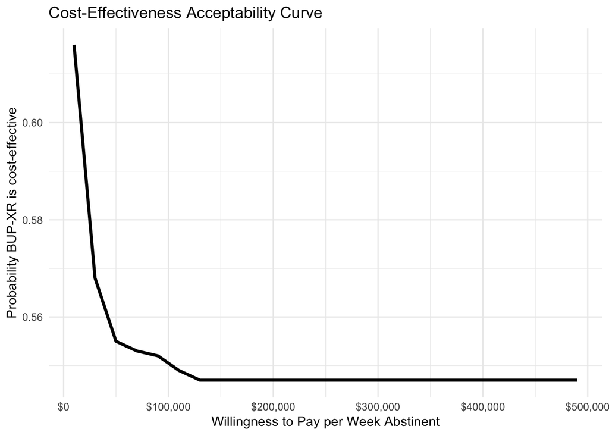

The proportion of bootstrap replicates in which the net monetary benefit (NMB) was greater than zero was calculated across willingness-to-pay (WTP) thresholds ranging from $10,000 to $500,000 per additional infant opioid treatment day avoided.

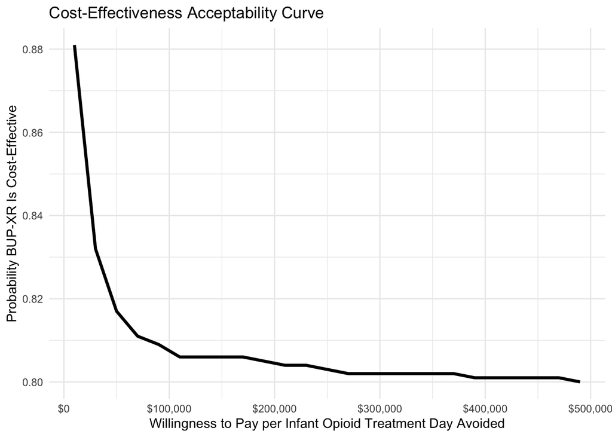

# Conclusions

1. BUP-XR was associated with significantly lower healthcare utilization costs than BUP-SL and demonstrated a high probability of being cost-effective. Adjusted primary healthcare costs were significantly lower over the first 6 months, with cost savings persisting through 12 months.
2. Although adjusted QALYs, expected abstinent weeks, and infant opioid treatment days consistently favored BUP-XR, neither outcome was statistically significantly different between treatment groups in this economic evaluation.
3. The effectiveness analyses differed from those of the original MOMs trial and therefore are not directly comparable. The original trial compared the proportion of weekly opioid-negative urine drug screens and directly analyzed observed infant opioid treatment outcomes, whereas our study estimated adjusted expected abstinent weeks using longitudinal g-computation and adjusted infant opioid treatment days using a covariate-adjusted two-part model. Despite these methodological differences, both studies consistently favored BUP-XR. The original MOMs trial demonstrated significantly greater maternal opioid abstinence during pregnancy with BUP-XR, while finding no statistically significant differences in neonatal opioid withdrawal syndrome treatment outcomes.
4. Overall, these findings demonstrate the economic value of BUP-XR. Although differences in maternal and infant effectiveness outcomes were not statistically significant in this analysis, the combination of significantly lower healthcare costs and a high probability of cost-effectiveness suggests that BUP-XR may provide favorable economic value while maintaining maternal and neonatal outcomes comparable to BUP-SL.

Division of Biostatistics

Department of Population Health Sciences

Licza Lobo, Jacob Parquet